# EFA for parent scales

## removing 36 because it doesn’t jive as well with other items conceptually

```r
scho_inv_fa2 <- parent_w1 %>%
  select(q37, q38, q39)

# alpha
alpha(scho_inv_fa2) # .79 (networking with other parents)
```

```
##
## Reliability analysis
## Call: alpha(x = scho_inv_fa2)
##
##   raw_alpha std.alpha G6(smc) average_r S/N   ase mean   sd median_r
##       0.79      0.79    0.72      0.55 3.7 0.037  2.5 0.57     0.55
##
##     95% confidence boundaries
##          lower alpha upper
## Feldt     0.71  0.79  0.86
## Duhachek  0.72  0.79  0.86
##
##  Reliability if an item is dropped:
##     raw_alpha std.alpha G6(smc) average_r S/N alpha se var.r med.r
## q37      0.78      0.78    0.64      0.64 3.6    0.045    NA  0.64
## q38      0.65      0.64    0.48      0.48 1.8    0.073    NA  0.48
## q39      0.71      0.71    0.55      0.55 2.4    0.059    NA  0.55
##
##  Item statistics
##      n raw.r std.r r.cor r.drop mean   sd
## q37 94  0.80  0.80  0.63   0.57  2.6 0.66
## q38 94  0.88  0.87  0.78   0.70  2.5 0.71
## q39 95  0.84  0.84  0.72   0.64  2.3 0.68
##
## Non missing response frequency for each item
##        1    2    3    4 miss
## q37 0.01 0.48 0.43 0.09 0.01
## q38 0.07 0.45 0.43 0.05 0.01
## q39 0.08 0.54 0.35 0.03 0.00
```

## Omega

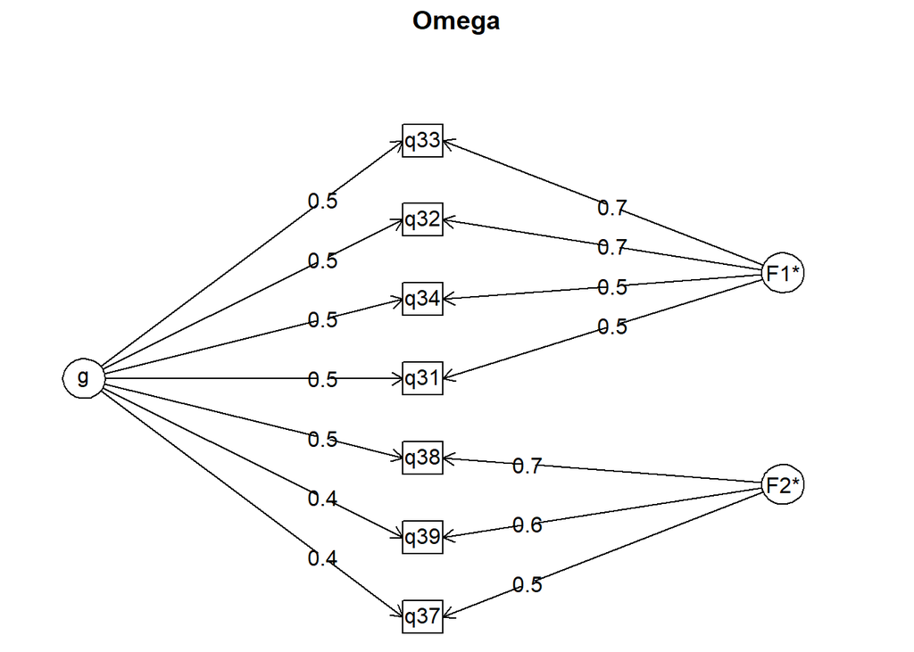

```
## Omega
## Call: omegah(m = m, nfactors = nfactors, fm = fm, key = key, flip = flip,
##     digits = digits, title = title, sl = sl, labels = labels,
##     plot = plot, n.obs = n.obs, rotate = rotate, Phi = Phi, option = option,
##     covar = covar)
## Alpha:                 0.82
## G.6:                   0.85
## Omega Hierarchical:    0.46
## Omega H asymptotic:    0.52
## Omega Total            0.88
##
## Schmid Leiman Factor loadings greater than  0.2
##        g   F1*   F2*   h2   h2   u2   p2  com
## q31 0.46  0.46       0.45 0.45 0.55 0.47 2.24
## q32 0.48  0.71       0.74 0.74 0.26 0.31 1.77
## q33 0.53  0.72       0.79 0.79 0.21 0.35 1.83
## q34 0.47  0.51       0.49 0.49 0.51 0.44 2.11
## q37 0.37        0.51 0.39 0.39 0.61 0.35 1.83
## q38 0.53        0.70 0.78 0.78 0.22 0.36 1.86
## q39 0.43        0.59 0.54 0.54 0.46 0.34 1.82
##
## With Sums of squares  of:
##   g F1* F2*  h2
## 1.5 1.5 1.1 2.7
##
## general/max  0.58   max/min =   2.32
## mean percent general =  0.37    with sd =  0.06 and cv of  0.15
## Explained Common Variance of the general factor =  0.37
##
## The degrees of freedom are 8  and the fit is  0.08
## The number of observations was  95  with Chi Square =  6.94  with prob <  0.54
## The root mean square of the residuals is  0.03
## The df corrected root mean square of the residuals is  0.05
## RMSEA index =  0  and the 10 % confidence intervals are  0 0.11
## BIC =  -29.49
##
## Compare this with the adequacy of just a general factor and no group factors
## The degrees of freedom for just the general factor are 14  and the fit is  1.53
## The number of observations was  95  with Chi Square =  137.96  with prob <  1.8e-22
## The root mean square of the residuals is  0.24
## The df corrected root mean square of the residuals is  0.3
##
## RMSEA index =  0.305  and the 10 % confidence intervals are  0.261 0.355
## BIC =  74.2
##
## Measures of factor score adequacy
##                                                   g  F1*  F2*
## Correlation of scores with factors             0.69 0.80 0.78
## Multiple R square of scores with factors       0.47 0.63 0.60
## Minimum correlation of factor score estimates -0.06 0.27 0.20
##
##  Total, General and Subset omega for each subset
##                                                  g  F1*  F2*
## Omega total for total scores and subscales    0.88 0.86 0.79
## Omega general for total scores and subscales  0.46 0.34 0.28
## Omega group for total scores and subscales    0.39 0.52 0.51
```

```r
scho_inv <- parent_w1 %>%
  select(q31, q32, q33, q34, q37, q38, q39)
omega(scho_inv, nfactors = 2, n.obs = 95, flip = T, plot = T) # alpha 0.82
```

```r
# warning : 3 factors are required fo identification
```

# comfort

Como madre/padre de esta escuela, siento que soy… 47. …parte de una comunidad con el personal de la escuela y los otros padres. ____ 48. …tratado/a con respeto, sabiendo que mis opiniones son importantes. ____ 49. …cómoda/o preguntando por un traductor y por materiales en español si los necesito. ____ 50. … capaz de hablar con maestros o administradores sobre grandes preocupaciones relacionados con mi joven. *51. …dedicada/o en creando un ambiente exitoso para todos los jóvenes.* _ 52. …feliz de que mi joven asista a esta escuela. *53. …bienvenido/a en la escuela de mi joven.* _

taps on parent comfort at school, except maybe item 51 about parent contributing

## The scale to factor analyze

```r
comfort <- parent_w1 %>%
  select(q47, q48, q49, q50, q51, q52, q53)
```

## kmo Kaiser-Meyer-Olkin factor

```r
KMO(comfort) # 0.83
```

```
## Kaiser-Meyer-Olkin factor adequacy
## Call: KMO(r = comfort)
## Overall MSA =  0.83
## MSA for each item =
##  q47  q48  q49  q50  q51  q52  q53
## 0.77 0.85 0.85 0.83 0.76 0.82 0.84
```

## Poly corr matrix

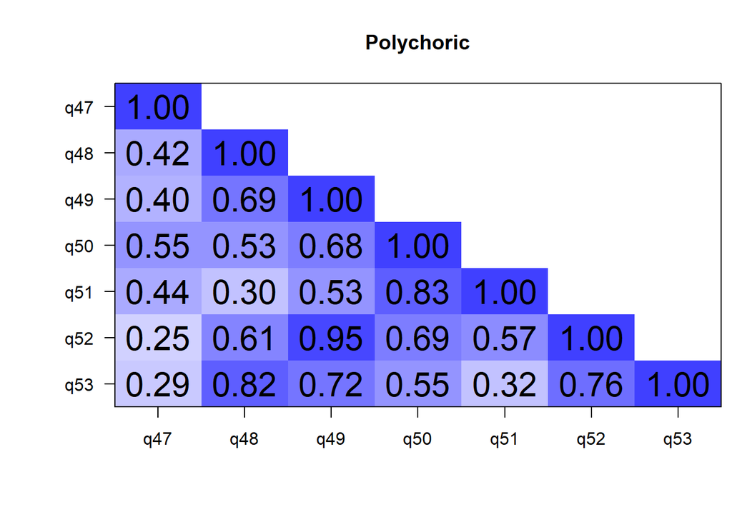

```r
poly <- polychoric(comfort)
cor.plot(poly$rho, numbers = T, upper = F, main = "Polychoric", show.legend = F) # all healthy corrs
```

## scree plot

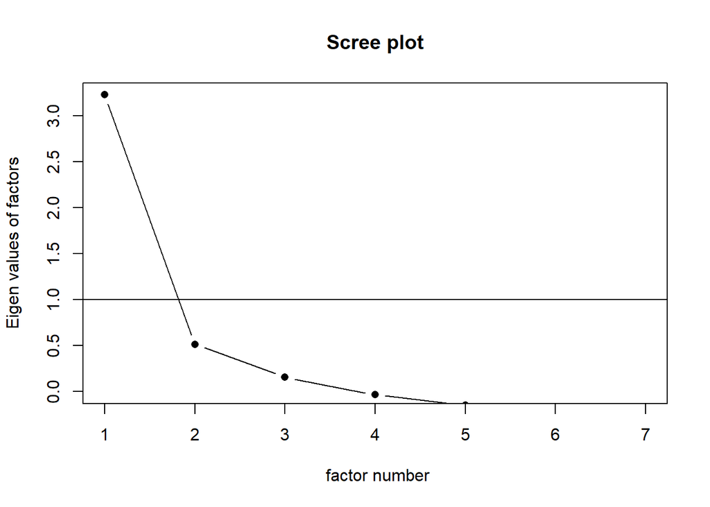

```r
scree(comfort, factors = TRUE, pc = FALSE, main = "Scree plot", hline = NULL, add = FALSE)
```

```r
# Scree plot clearly shows 1 factor solution
```

## parallel test

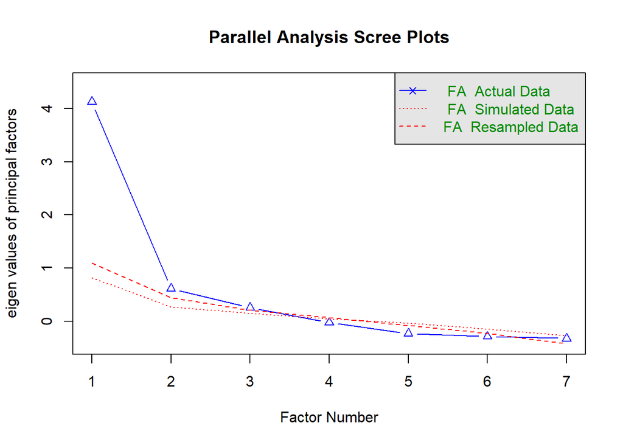

```
## Parallel analysis suggests that the number of factors =  3  and the number of components =  NA
```

```r
fa.parallel(comfort, n.obs=NULL, fm="uls", fa="fa", main="Parallel Analysis Scree Plots", cor="poly", use="pairwise", plot=TRUE)
```

```r
# Parallel analysis suggests that the number of factors =  3
# warnings
```

## EFA using ULS

```r
factor_test_uls <- fa(comfort, n.obs = 95, rotate = "oblimin", fm = "uls", cor = "poly", nfactors = 2)
factor_test_uls
```

```
## Factor Analysis using method =  uls
## Call: fa(r = comfort, nfactors = 2, n.obs = 95, rotate = "oblimin",
##     fm = "uls", cor = "poly")
## Standardized loadings (pattern matrix) based upon correlation matrix
##      ULS1  ULS2   h2    u2 com
## q47  0.13  0.44 0.27 0.732 1.2
## q48  0.84 -0.04 0.67 0.330 1.0
## q49  0.75  0.24 0.83 0.172 1.2
## q50  0.19  0.83 0.91 0.087 1.1
## q51 -0.09  0.95 0.81 0.191 1.0
## q52  0.73  0.24 0.78 0.216 1.2
## q53  0.98 -0.12 0.85 0.150 1.0
##
##                       ULS1 ULS2
## SS loadings           3.02 2.10
## Proportion Var        0.43 0.30
## Cumulative Var        0.43 0.73
## Proportion Explained  0.59 0.41
## Cumulative Proportion 0.59 1.00
##
##  With factor correlations of
##      ULS1 ULS2
## ULS1 1.00 0.55
## ULS2 0.55 1.00
##
## Mean item complexity =  1.1
## Test of the hypothesis that 2 factors are sufficient.
##
## df null model =  21  with the objective function =  7.55 with Chi Square =  686.07
## df of  the model are 8  and the objective function was  2.08
##
## The root mean square of the residuals (RMSR) is  0.06
## The df corrected root mean square of the residuals is  0.1
##
## The harmonic n.obs is  93 with the empirical chi square  15.71  with prob <  0.047
## The total n.obs was  95  with Likelihood Chi Square =  186.07  with prob <  5.5e-36
##
## Tucker Lewis Index of factoring reliability =  0.286
## RMSEA index =  0.484  and the 90 % confidence intervals are  0.427 0.548
## BIC =  149.64
## Fit based upon off diagonal values = 0.99
## Measures of factor score adequacy
##                                                   ULS1 ULS2
## Correlation of (regression) scores with factors   0.98 0.97
## Multiple R square of scores with factors          0.96 0.95
## Minimum correlation of possible factor scores     0.91 0.90
```

```r
#going for 2 factors, because at least one factor would have 2 items
# no warnings
```

## Factor 1: welcome

48. …tratado/a con respeto, sabiendo que mis opiniones son importantes. ____
49. …cómoda/o preguntando por un traductor y por materiales en español si los necesito. ____
50. …feliz de que mi joven asista a esta escuela. ___
51. …bienvenido/a en la escuela de mi joven. ____

```r
comfort_fa1 <- parent_w1 %>%
  select(q48, q49, q52, q53)
# alpha
alpha(comfort_fa1) # 0.86
```

```
##
## Reliability analysis
## Call: alpha(x = comfort_fa1)
##
##   raw_alpha std.alpha G6(smc) average_r S/N   ase mean   sd median_r
##       0.86      0.86    0.83       0.6 6.1 0.025  3.2 0.41     0.62
##
##     95% confidence boundaries
##          lower alpha upper
## Feldt     0.80  0.86   0.9
## Duhachek  0.81  0.86   0.9
##
##  Reliability if an item is dropped:
##     raw_alpha std.alpha G6(smc) average_r S/N alpha se  var.r med.r
## q48      0.86      0.86    0.81      0.68 6.2    0.025 0.0023  0.65
## q49      0.80      0.80    0.74      0.58 4.1    0.036 0.0084  0.60
## q52      0.81      0.81    0.75      0.59 4.3    0.034 0.0033  0.60
## q53      0.80      0.80    0.75      0.58 4.1    0.037 0.0182  0.53
##
##  Item statistics
##      n raw.r std.r r.cor r.drop mean   sd
## q48 94  0.79  0.77  0.65   0.61  3.0 0.55
## q49 94  0.85  0.86  0.81   0.75  3.2 0.45
## q52 95  0.85  0.85  0.80   0.72  3.3 0.49
## q53 95  0.86  0.86  0.80   0.75  3.2 0.49
##
## Non missing response frequency for each item
##        1    2    3    4 miss
## q48 0.01 0.12 0.73 0.14 0.01
## q49 0.00 0.02 0.77 0.21 0.01
## q52 0.00 0.02 0.68 0.29 0.00
## q53 0.00 0.05 0.74 0.21 0.00
```

## Factor 2: included (not included in multiple regression analyses)

47. …parte de una comunidad con el personal de la escuela y los otros padres. ____
48. … capaz de hablar con maestros o administradores sobre grandes preocupaciones relacionados con mi joven. ___
49. …dedicada/o en creando un ambiente exitoso para todos los jóvenes. ____

```r
comfort_fa2 <- parent_w1 %>%
  select(q47, q50, q51)
# alpha
alpha(comfort_fa2) # 0.70
```

```
##
## Reliability analysis
## Call: alpha(x = comfort_fa2)
##
##   raw_alpha std.alpha G6(smc) average_r S/N   ase mean   sd median_r
##        0.7      0.72    0.65      0.46 2.6 0.054    3 0.43     0.42
##
##     95% confidence boundaries
##          lower alpha upper
## Feldt     0.58   0.7  0.79
## Duhachek  0.60   0.7  0.81
##
##  Reliability if an item is dropped:
##     raw_alpha std.alpha G6(smc) average_r S/N alpha se var.r med.r
## q47      0.75      0.76    0.61      0.61 3.1    0.051    NA  0.61
## q50      0.52      0.53    0.36      0.36 1.1    0.096    NA  0.36
## q51      0.58      0.59    0.42      0.42 1.4    0.083    NA  0.42
##
##  Item statistics
##      n raw.r std.r r.cor r.drop mean   sd
## q47 94  0.79  0.74  0.50   0.44  2.8 0.63
## q50 94  0.82  0.84  0.74   0.61  3.1 0.48
## q51 92  0.80  0.82  0.70   0.55  3.0 0.51
##
## Non missing response frequency for each item
##        1    2    3    4 miss
## q47 0.03 0.20 0.67 0.10 0.01
## q50 0.01 0.03 0.79 0.17 0.01
## q51 0.01 0.08 0.77 0.14 0.03
```

## Omega

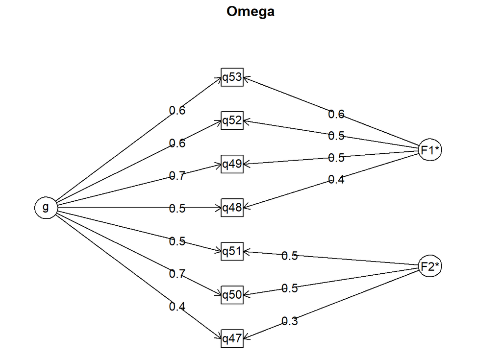

```
## Omega
## Call: omegah(m = m, nfactors = nfactors, fm = fm, key = key, flip = flip,
##     digits = digits, title = title, sl = sl, labels = labels,
##     plot = plot, n.obs = n.obs, rotate = rotate, Phi = Phi, option = option,
##     covar = covar)
## Alpha:                 0.84
## G.6:                   0.86
## Omega Hierarchical:    0.63
## Omega H asymptotic:    0.71
## Omega Total            0.88
##
## Schmid Leiman Factor loadings greater than  0.2
##        g   F1*   F2*   h2   h2   u2   p2  com
## q47 0.36        0.32 0.23 0.23 0.77 0.56 1.97
## q48 0.50  0.42       0.43 0.43 0.57 0.58 1.95
## q49 0.68  0.48       0.70 0.70 0.30 0.65 1.87
## q50 0.70        0.48 0.74 0.74 0.26 0.66 1.87
## q51 0.53        0.53 0.56 0.56 0.44 0.50 2.03
## q52 0.63  0.49       0.64 0.64 0.36 0.62 1.91
## q53 0.59  0.60       0.72 0.72 0.28 0.49 2.03
##
## With Sums of squares  of:
##    g  F1*  F2*   h2
## 2.36 1.03 0.64 2.52
##
## general/max  0.94   max/min =   3.94
## mean percent general =  0.58    with sd =  0.07 and cv of  0.12
## Explained Common Variance of the general factor =  0.59
##
## The degrees of freedom are 8  and the fit is  0.17
## The number of observations was  95  with Chi Square =  14.9  with prob <  0.061
## The root mean square of the residuals is  0.04
## The df corrected root mean square of the residuals is  0.07
## RMSEA index =  0.095  and the 10 % confidence intervals are  0 0.17
## BIC =  -21.53
##
## Compare this with the adequacy of just a general factor and no group factors
## The degrees of freedom for just the general factor are 14  and the fit is  0.88
## The number of observations was  95  with Chi Square =  79.73  with prob <  3.2e-11
## The root mean square of the residuals is  0.16
## The df corrected root mean square of the residuals is  0.2
##
## RMSEA index =  0.222  and the 10 % confidence intervals are  0.177 0.272
## BIC =  15.98
##
## Measures of factor score adequacy
##                                                  g   F1*   F2*
## Correlation of scores with factors            0.81  0.69  0.66
## Multiple R square of scores with factors      0.65  0.48  0.44
## Minimum correlation of factor score estimates 0.30 -0.04 -0.12
##
##  Total, General and Subset omega for each subset
##                                                  g  F1*  F2*
## Omega total for total scores and subscales    0.88 0.86 0.74
## Omega general for total scores and subscales  0.63 0.51 0.44
## Omega group for total scores and subscales    0.23 0.35 0.31
```

```r
omega(comfort, nfactors = 2, n.obs = 95, flip = T, plot = T) # 0.84
```

# endorse & rels

Como madre/padre en esta escuela, estoy segura/o de que… 54. … esta escuela es un buen lugar para mi joven. _____ 55. … el personal de la escuela de mi joven está haciendo cosas buenas por ella / el. _____ 56. … la gente en la escuela de mi joven es confiable. _____ 57. … la escuela de mi joven hace un buen trabajo preparando a los jóvenes para sus futuros. _____ 58. … puedo encontrar ayuda para mi joven si él / ella está batallando en una clase. *59. … los maestros de mi joven se preocupan por ella/el.* _ 60. … maestros y administradores trabajan juntos para crear un ambiente seguro y acogedor para todos. ____ 61. … hay muchas oportunidades para la involucración de los padres. ____ 62. … puedo tener una conversación honesta y respetuosa sobre mi joven con su maestro. *63. …puedo trabajar con un maestro para resolver cualquier problema que tenga mi joven en la escuela.* __

## The scale to factor analyze

```r
rels <- parent_w1 %>%
  select(q54, q55, q56, q57, q58, q59, q60, q61, q62, q63)
```

## kmo Kaiser-Meyer-Olkin factor

```r
KMO(rels) # 0.88
```

```
## Kaiser-Meyer-Olkin factor adequacy
## Call: KMO(r = rels)
## Overall MSA =  0.88
## MSA for each item =
##  q54  q55  q56  q57  q58  q59  q60  q61  q62  q63
## 0.90 0.89 0.86 0.92 0.85 0.91 0.87 0.90 0.90 0.78
```

## Poly corr matrix

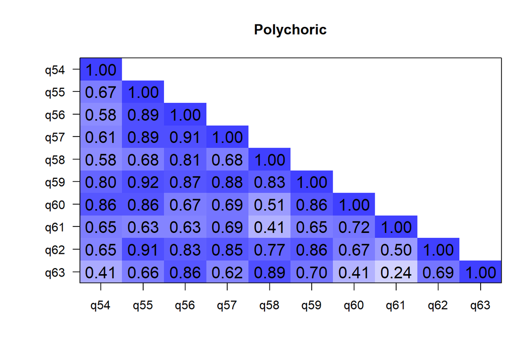

```r
poly <- polychoric(rels)
cor.plot(poly$rho, numbers = T, upper = F, main = "Polychoric", show.legend = F) # all healthy corrs
```

## scree plot

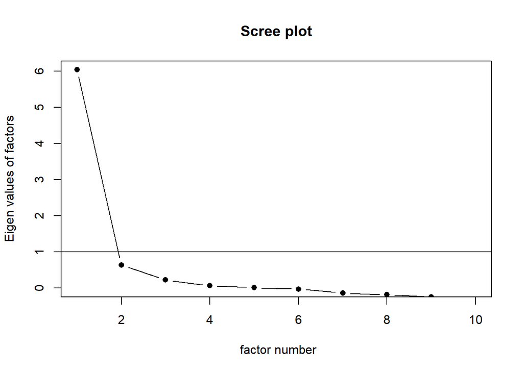

```r
scree(rels, factors = TRUE, pc = FALSE, main = "Scree plot", hline = NULL, add = FALSE)
```

```r
# Scree plot clearly shows 1 factor solution
```

## parallel test

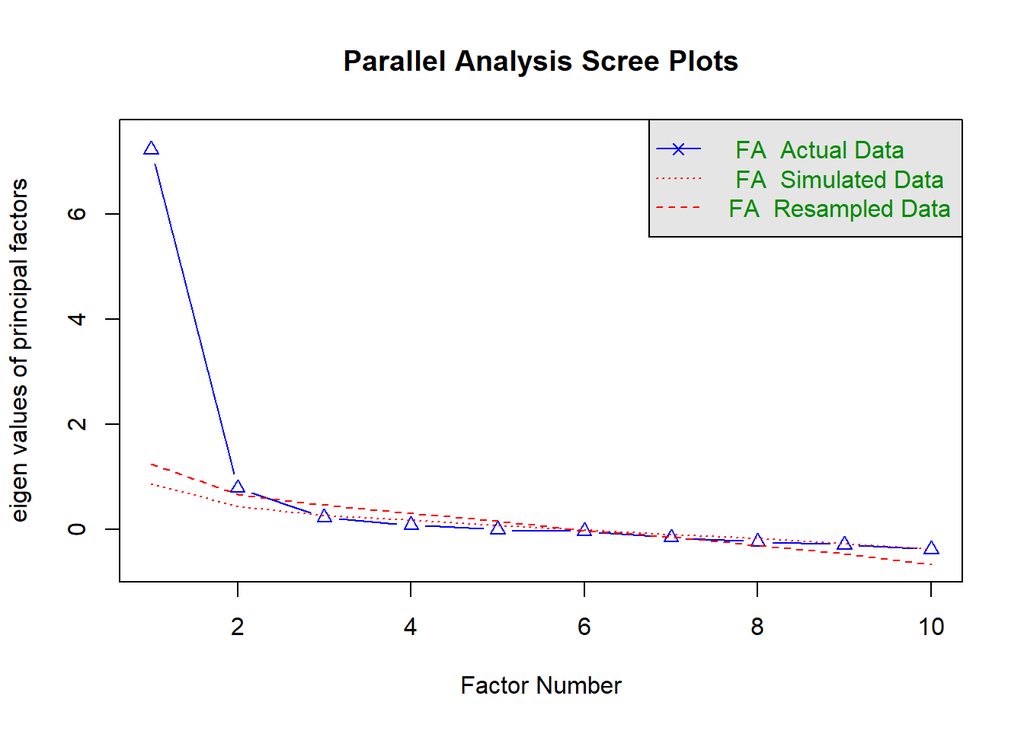

```
## Parallel analysis suggests that the number of factors =  2  and the number of components =  NA
```

```r
fa.parallel(rels, n.obs=NULL, fm="uls", fa="fa", main="Parallel Analysis Scree Plots", cor="poly", use="pairwise", plot=TRUE)
```

```r
# Parallel analysis suggests that the number of factors =  2
# warnings
```

## EFA using ULS

```r
factor_test_uls <- fa(rels, n.obs = 95, rotate = "oblimin", fm = "uls", cor = "poly", nfactors = 2)
factor_test_uls
```

```
## Factor Analysis using method =  uls
## Call: fa(r = rels, nfactors = 2, n.obs = 95, rotate = "oblimin", fm = "uls",
##     cor = "poly")
## Standardized loadings (pattern matrix) based upon correlation matrix
##      ULS1  ULS2   h2    u2 com
## q54  0.83 -0.01 0.68 0.320 1.0
## q55  0.70  0.35 0.90 0.103 1.5
## q56  0.42  0.65 0.92 0.081 1.7
## q57  0.62  0.38 0.81 0.190 1.7
## q58  0.16  0.80 0.81 0.189 1.1
## q59  0.71  0.39 0.96 0.035 1.6
## q60  1.02 -0.13 0.91 0.093 1.0
## q61  0.85 -0.14 0.61 0.391 1.1
## q62  0.49  0.52 0.80 0.201 2.0
## q63 -0.12  1.04 0.95 0.050 1.0
##
##                       ULS1 ULS2
## SS loadings           4.89 3.46
## Proportion Var        0.49 0.35
## Cumulative Var        0.49 0.83
## Proportion Explained  0.59 0.41
## Cumulative Proportion 0.59 1.00
##
##  With factor correlations of
##      ULS1 ULS2
## ULS1 1.00 0.58
## ULS2 0.58 1.00
##
## Mean item complexity =  1.4
## Test of the hypothesis that 2 factors are sufficient.
##
## df null model =  45  with the objective function =  74.59 with Chi Square =  6700.87
## df of  the model are 26  and the objective function was  61.13
##
## The root mean square of the residuals (RMSR) is  0.05
## The df corrected root mean square of the residuals is  0.06
##
## The harmonic n.obs is  92 with the empirical chi square  17.24  with prob <  0.9
## The total n.obs was  95  with Likelihood Chi Square =  5410.1  with prob <  0
##
## Tucker Lewis Index of factoring reliability =  -0.421
## RMSEA index =  1.476  and the 90 % confidence intervals are  1.451 NA
## BIC =  5291.7
## Fit based upon off diagonal values = 1
## Measures of factor score adequacy
##                                                   ULS1 ULS2
## Correlation of (regression) scores with factors   0.99 0.98
## Multiple R square of scores with factors          0.97 0.97
## Minimum correlation of possible factor scores     0.94 0.93
```

```r
# matrix nonpositive definite, items 58, 60 and 63
```

## removing items 58, 60 and 63

```r
rels <- parent_w1 %>%
  select(q54, q55, q56, q57, q59, q61, q62)
```

## EFA using ULS - iteration 2 (with 1 and 2 factors)

```r
factor_test_uls <- fa(rels, n.obs = 95, rotate = "oblimin", fm = "uls", cor = "poly", nfactors = 2)
factor_test_uls
```

```
## Factor Analysis using method =  uls
## Call: fa(r = rels, nfactors = 2, n.obs = 95, rotate = "oblimin", fm = "uls",
##     cor = "poly")
## Standardized loadings (pattern matrix) based upon correlation matrix
##     ULS1  ULS2   h2      u2 com
## q54 0.02  0.99 1.01 -0.0057 1.0
## q55 1.01 -0.02 1.00 -0.0027 1.0
## q56 1.02 -0.08 0.94  0.0645 1.0
## q57 0.99 -0.02 0.95  0.0512 1.0
## q59 0.77  0.28 0.96  0.0448 1.3
## q61 0.42  0.35 0.50  0.5048 1.9
## q62 0.87  0.04 0.81  0.1864 1.0
##
##                       ULS1 ULS2
## SS loadings           4.77 1.39
## Proportion Var        0.68 0.20
## Cumulative Var        0.68 0.88
## Proportion Explained  0.77 0.23
## Cumulative Proportion 0.77 1.00
##
##  With factor correlations of
##      ULS1 ULS2
## ULS1 1.00 0.67
## ULS2 0.67 1.00
##
## Mean item complexity =  1.2
## Test of the hypothesis that 2 factors are sufficient.
##
## df null model =  21  with the objective function =  31.65 with Chi Square =  2875.3
## df of  the model are 8  and the objective function was  20.65
##
## The root mean square of the residuals (RMSR) is  0.03
## The df corrected root mean square of the residuals is  0.05
##
## The harmonic n.obs is  93 with the empirical chi square  4.07  with prob <  0.85
## The total n.obs was  95  with Likelihood Chi Square =  1848.17  with prob <  0
##
## Tucker Lewis Index of factoring reliability =  -0.718
## RMSEA index =  1.556  and the 90 % confidence intervals are  1.505 1.625
## BIC =  1811.74
## Fit based upon off diagonal values = 1
```

```r
# matrix nonpositive definite, items loading >1 and crossloading items.

factor_test_uls <- fa(rels, n.obs = 95, rotate = "oblimin", fm = "uls", cor = "poly", nfactors = 1)
factor_test_uls
```

```
## Factor Analysis using method =  uls
## Call: fa(r = rels, nfactors = 1, n.obs = 95, rotate = "oblimin", fm = "uls",
##     cor = "poly")
## Standardized loadings (pattern matrix) based upon correlation matrix
##     ULS1   h2    u2 com
## q54 0.73 0.53 0.466   1
## q55 0.99 0.98 0.021   1
## q56 0.94 0.89 0.114   1
## q57 0.96 0.92 0.076   1
## q59 0.98 0.97 0.035   1
## q61 0.69 0.47 0.528   1
## q62 0.90 0.81 0.192   1
##
##                ULS1
## SS loadings    5.57
## Proportion Var 0.80
##
## Mean item complexity =  1
## Test of the hypothesis that 1 factor is sufficient.
##
## df null model =  21  with the objective function =  31.65 with Chi Square =  2875.3
## df of  the model are 14  and the objective function was  21.62
##
## The root mean square of the residuals (RMSR) is  0.06
## The df corrected root mean square of the residuals is  0.07
##
## The harmonic n.obs is  93 with the empirical chi square  13.4  with prob <  0.5
## The total n.obs was  95  with Likelihood Chi Square =  1949.49  with prob <  0
##
## Tucker Lewis Index of factoring reliability =  -0.025
## RMSEA index =  1.206  and the 90 % confidence intervals are  1.168 1.258
## BIC =  1885.74
## Fit based upon off diagonal values = 0.99
## Measures of factor score adequacy
##                                                   ULS1
## Correlation of (regression) scores with factors   1.00
## Multiple R square of scores with factors          1.00
## Minimum correlation of possible factor scores     0.99
```

```r
# matrix nonpositive definite
```

## trying only a couple of items that tap more closely on school endorsemnet

54. … esta escuela es un buen lugar para mi joven. _____
55. … el personal de la escuela de mi joven está haciendo cosas buenas por ella / el. _____
56. … la gente en la escuela de mi joven es confiable. _____
57. … la escuela de mi joven hace un buen trabajo preparando a los jóvenes para sus futuros. _____

```r
endorse <- parent_w1 %>%
  select(q54, q55, q56, q57)

factor_test_uls <- fa(endorse, n.obs = 95, rotate = "oblimin", fm = "uls", cor = "poly", nfactors = 1)
factor_test_uls
```

```
## Factor Analysis using method =  uls
## Call: fa(r = endorse, nfactors = 1, n.obs = 95, rotate = "oblimin",
##     fm = "uls", cor = "poly")
## Standardized loadings (pattern matrix) based upon correlation matrix
##     ULS1   h2      u2 com
## q54 0.65 0.42  0.5776   1
## q55 1.00 1.00 -0.0032   1
## q56 0.96 0.93  0.0740   1
## q57 0.97 0.94  0.0572   1
##
##                ULS1
## SS loadings    3.29
## Proportion Var 0.82
##
## Mean item complexity =  1
## Test of the hypothesis that 1 factor is sufficient.
##
## df null model =  6  with the objective function =  6.08 with Chi Square =  558.11
## df of  the model are 2  and the objective function was  0.32
##
## The root mean square of the residuals (RMSR) is  0.02
## The df corrected root mean square of the residuals is  0.03
##
## The harmonic n.obs is  94 with the empirical chi square  0.36  with prob <  0.84
## The total n.obs was  95  with Likelihood Chi Square =  29.06  with prob <  4.9e-07
##
## Tucker Lewis Index of factoring reliability =  0.852
## RMSEA index =  0.377  and the 90 % confidence intervals are  0.265 0.507
## BIC =  19.95
## Fit based upon off diagonal values = 1
```

```r
# no warnings but items 55 with a loading of 1
```

## removing 55 bec was redundant with 57

```r
endorse <- parent_w1 %>%
  select(q54, q56, q57)

factor_test_uls <- fa(endorse, n.obs = 95, rotate = "oblimin", fm = "uls", cor = "poly", nfactors = 1)
factor_test_uls
```

```
## Factor Analysis using method =  uls
## Call: fa(r = endorse, nfactors = 1, n.obs = 95, rotate = "oblimin",
##     fm = "uls", cor = "poly")
## Standardized loadings (pattern matrix) based upon correlation matrix
##     ULS1  h2     u2 com
## q54 0.63 0.4 0.6030   1
## q56 0.95 0.9 0.0961   1
## q57 1.00 1.0 0.0041   1
##
##                ULS1
## SS loadings    2.30
## Proportion Var 0.77
##
## Mean item complexity =  1
## Test of the hypothesis that 1 factor is sufficient.
##
## df null model =  3  with the objective function =  2.82 with Chi Square =  259.64
## df of  the model are 0  and the objective function was  0
##
## The root mean square of the residuals (RMSR) is  0
## The df corrected root mean square of the residuals is  NA
##
## The harmonic n.obs is  93 with the empirical chi square  0  with prob <  NA
## The total n.obs was  95  with Likelihood Chi Square =  0.01  with prob <  NA
##
## Tucker Lewis Index of factoring reliability =  -Inf
## Fit based upon off diagonal values = 1
## Measures of factor score adequacy
##                                                   ULS1
## Correlation of (regression) scores with factors   1.00
## Multiple R square of scores with factors          1.00
## Minimum correlation of possible factor scores     0.99
```

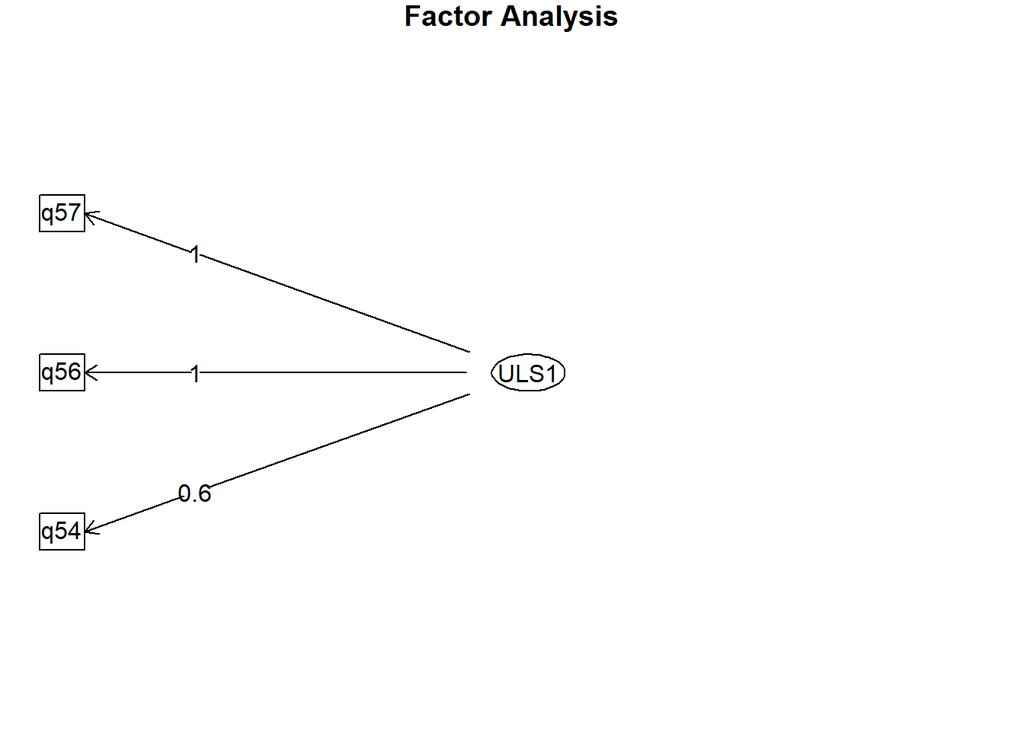

```r
fa.diagram(factor_test_uls)
```

```r
# no warnings
```

## alpha

```r
alpha(endorse) # 0.79
```

```
##
## Reliability analysis
## Call: alpha(x = endorse)
##
##   raw_alpha std.alpha G6(smc) average_r S/N   ase mean   sd median_r
##       0.79      0.81    0.77      0.58 4.2 0.038  3.2 0.41     0.51
##
##     95% confidence boundaries
##          lower alpha upper
## Feldt     0.71  0.79  0.86
## Duhachek  0.72  0.79  0.87
##
##  Reliability if an item is dropped:
##     raw_alpha std.alpha G6(smc) average_r S/N alpha se var.r med.r
## q54      0.87      0.88    0.78      0.78 7.0    0.026    NA  0.78
## q56      0.66      0.67    0.51      0.51 2.1    0.068    NA  0.51
## q57      0.63      0.64    0.47      0.47 1.8    0.073    NA  0.47
##
##  Item statistics
##      n raw.r std.r r.cor r.drop mean   sd
## q54 95  0.81  0.77  0.56   0.52  3.2 0.55
## q56 93  0.86  0.88  0.83   0.70  3.2 0.44
## q57 94  0.88  0.90  0.86   0.73  3.2 0.45
##
## Non missing response frequency for each item
##        1    2    3    4 miss
## q54 0.01 0.04 0.71 0.24 0.00
## q56 0.00 0.03 0.78 0.18 0.02
## q57 0.00 0.03 0.78 0.19 0.01
```

# teacher support

Como madre/padre en esta escuela, estoy segura/o de que… 58. … puedo encontrar ayuda para mi joven si él / ella está batallando en una clase. *59. … los maestros de mi joven se preocupan por ella/el.* _ 60. … maestros y administradores trabajan juntos para crear un ambiente seguro y acogedor para todos. ____ 61. … hay muchas oportunidades para la involucración de los padres. ____ 62. … puedo tener una conversación honesta y respetuosa sobre mi joven con su maestro. *63. …puedo trabajar con un maestro para resolver cualquier problema que tenga mi joven en la escuela.* __

## The scale to factor analyze

```r
support <- parent_w1 %>%
  select(q58, q59, q60, q61, q62, q63)
```

## kmo Kaiser-Meyer-Olkin

```r
KMO(support) # 0.81
```

```
## Kaiser-Meyer-Olkin factor adequacy
## Call: KMO(r = support)
## Overall MSA =  0.81
## MSA for each item =
##  q58  q59  q60  q61  q62  q63
## 0.79 0.82 0.77 0.84 0.90 0.80
```

## Poly corr matrix

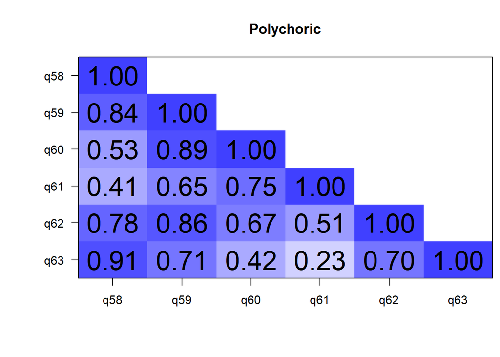

```r
poly <- polychoric(support)
cor.plot(poly$rho, numbers = T, upper = F, main = "Polychoric", show.legend = F) # all healthy corrs
```

## scree plot

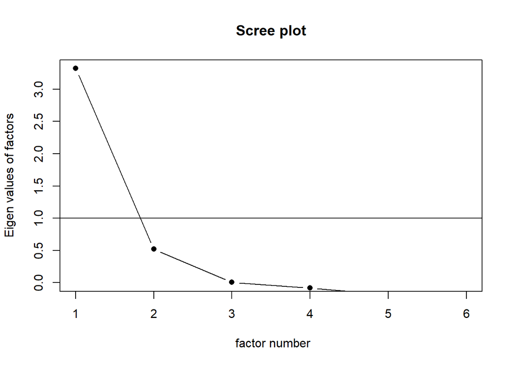

```r
scree(support, factors = TRUE, pc = FALSE, main = "Scree plot", hline = NULL, add = FALSE)
```

```r
# Scree plot shows 1 factor solution
```

## parallel test

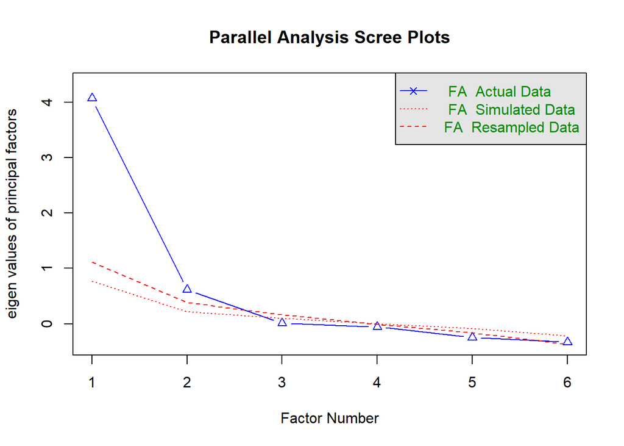

```
## Parallel analysis suggests that the number of factors =  2  and the number of components =  NA
```

```r
fa.parallel(support, n.obs=NULL, fm="uls", fa="fa", main="Parallel Analysis Scree Plots", cor="poly", use="pairwise", plot=TRUE)
```

```r
# Parallel analysis suggests that the number of factors =  2
# warnings
```

## EFA using ULS - 1 and 2 factors

```r
factor_test_uls <- fa(support, n.obs = 95, rotate = "oblimin", fm = "uls", cor = "poly", nfactors = 2)
factor_test_uls
```

```
## Factor Analysis using method =  uls
## Call: fa(r = support, nfactors = 2, n.obs = 95, rotate = "oblimin",
##     fm = "uls", cor = "poly")
## Standardized loadings (pattern matrix) based upon correlation matrix
##      ULS1  ULS2   h2     u2 com
## q58  0.91  0.10 0.94 0.0625 1.0
## q59  0.46  0.67 1.00 0.0029 1.8
## q60 -0.03  0.99 0.95 0.0464 1.0
## q61 -0.10  0.81 0.58 0.4155 1.0
## q62  0.56  0.42 0.74 0.2633 1.9
## q63  1.01 -0.11 0.91 0.0925 1.0
##
##                       ULS1 ULS2
## SS loadings           2.60 2.51
## Proportion Var        0.43 0.42
## Cumulative Var        0.43 0.85
## Proportion Explained  0.51 0.49
## Cumulative Proportion 0.51 1.00
##
##  With factor correlations of
##      ULS1 ULS2
## ULS1 1.00 0.53
## ULS2 0.53 1.00
##
## Mean item complexity =  1.3
## Test of the hypothesis that 2 factors are sufficient.
##
## df null model =  15  with the objective function =  26.8 with Chi Square =  2443.44
## df of  the model are 4  and the objective function was  18.76
##
## The root mean square of the residuals (RMSR) is  0.02
## The df corrected root mean square of the residuals is  0.03
##
## The harmonic n.obs is  91 with the empirical chi square  0.73  with prob <  0.95
## The total n.obs was  95  with Likelihood Chi Square =  1685.56  with prob <  0
##
## Tucker Lewis Index of factoring reliability =  -1.635
## RMSEA index =  2.104  and the 90 % confidence intervals are  2.031 2.2
## BIC =  1667.34
## Fit based upon off diagonal values = 1
## Measures of factor score adequacy
##                                                   ULS1 ULS2
## Correlation of (regression) scores with factors   0.98 0.99
## Multiple R square of scores with factors          0.97 0.98
## Minimum correlation of possible factor scores     0.94 0.96
```

```r
# matrix nonpositive definite

factor_test_uls <- fa(support, n.obs = 95, rotate = "oblimin", fm = "uls", cor = "poly", nfactors = 1)
factor_test_uls
```

```
## Factor Analysis using method =  uls
## Call: fa(r = support, nfactors = 1, n.obs = 95, rotate = "oblimin",
##     fm = "uls", cor = "poly")
## Standardized loadings (pattern matrix) based upon correlation matrix
##     ULS1   h2     u2 com
## q58 0.86 0.75  0.253   1
## q59 1.01 1.02 -0.021   1
## q60 0.79 0.62  0.383   1
## q61 0.60 0.36  0.640   1
## q62 0.88 0.78  0.225   1
## q63 0.74 0.54  0.457   1
##
##                ULS1
## SS loadings    4.06
## Proportion Var 0.68
##
## Mean item complexity =  1
## Test of the hypothesis that 1 factor is sufficient.
##
## df null model =  15  with the objective function =  26.8 with Chi Square =  2443.44
## df of  the model are 9  and the objective function was  21.59
##
## The root mean square of the residuals (RMSR) is  0.14
## The df corrected root mean square of the residuals is  0.17
##
## The harmonic n.obs is  91 with the empirical chi square  49.92  with prob <  1.1e-07
## The total n.obs was  95  with Likelihood Chi Square =  1953.82  with prob <  0
##
## Tucker Lewis Index of factoring reliability =  -0.345
## RMSEA index =  1.508  and the 90 % confidence intervals are  1.46 1.573
## BIC =  1912.84
## Fit based upon off diagonal values = 0.96
## Measures of factor score adequacy
##                                                   ULS1
## Correlation of (regression) scores with factors   0.99
## Multiple R square of scores with factors          0.98
## Minimum correlation of possible factor scores     0.96
```

```r
# matrix nonpositive definite
```

## removing 60 and 61 because doesn’t appear to jive well with other items

60. … maestros y administradores trabajan juntos para crear un ambiente seguro y acogedor para todos. ____
61. … hay muchas oportunidades para la involucración de los padres. ____

```r
support <- parent_w1 %>%
  select(q58, q59, q62, q63)
```

## EFA using ULS

```r
# EFA using ULS
factor_test_uls <- fa(support, n.obs = 95, rotate = "oblimin", fm = "uls", cor = "poly", nfactors = 1)
factor_test_uls
```

```
## Factor Analysis using method =  uls
## Call: fa(r = support, nfactors = 1, n.obs = 95, rotate = "oblimin",
##     fm = "uls", cor = "poly")
## Standardized loadings (pattern matrix) based upon correlation matrix
##     ULS1   h2    u2 com
## q58 0.98 0.95 0.047   1
## q59 0.92 0.85 0.153   1
## q62 0.86 0.74 0.260   1
## q63 0.85 0.73 0.272   1
##
##                ULS1
## SS loadings    3.27
## Proportion Var 0.82
##
## Mean item complexity =  1
## Test of the hypothesis that 1 factor is sufficient.
##
## df null model =  6  with the objective function =  5.27 with Chi Square =  483.57
## df of  the model are 2  and the objective function was  1.24
##
## The root mean square of the residuals (RMSR) is  0.07
## The df corrected root mean square of the residuals is  0.11
##
## The harmonic n.obs is  92 with the empirical chi square  4.76  with prob <  0.092
## The total n.obs was  95  with Likelihood Chi Square =  112.68  with prob <  3.4e-25
##
## Tucker Lewis Index of factoring reliability =  0.3
## RMSEA index =  0.763  and the 90 % confidence intervals are  0.65 0.891
## BIC =  103.57
## Fit based upon off diagonal values = 0.99
## Measures of factor score adequacy
##                                                   ULS1
## Correlation of (regression) scores with factors   1.00
## Multiple R square of scores with factors          0.99
## Minimum correlation of possible factor scores     0.98
```

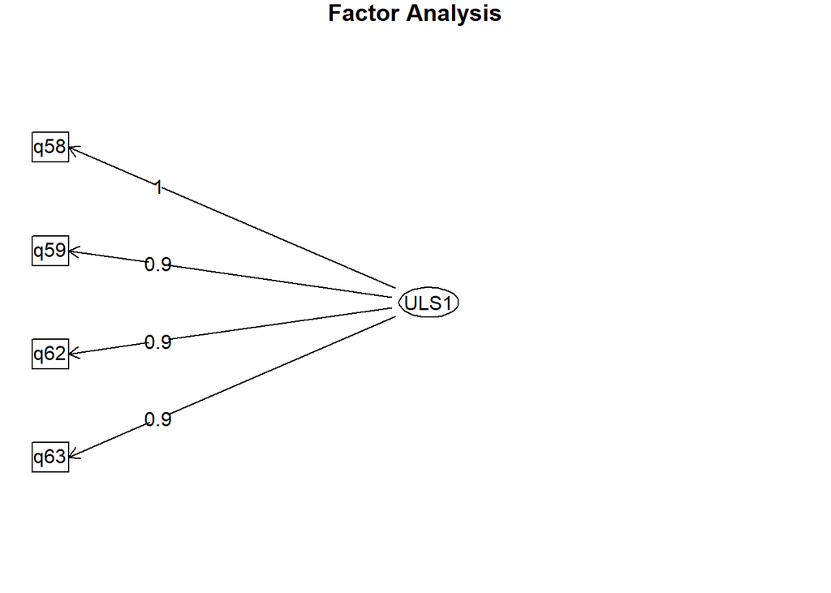

```r
fa.diagram(factor_test_uls)
```

```r
# no warnings!
```

```r
alpha(support) # 0.88
```

```
##
## Reliability analysis
## Call: alpha(x = support)
##
##   raw_alpha std.alpha G6(smc) average_r S/N  ase mean   sd median_r
##       0.88      0.88    0.86      0.65 7.3 0.02  3.2 0.41     0.66
##
##     95% confidence boundaries
##          lower alpha upper
## Feldt     0.84  0.88  0.92
## Duhachek  0.84  0.88  0.92
##
##  Reliability if an item is dropped:
##     raw_alpha std.alpha G6(smc) average_r S/N alpha se  var.r med.r
## q58      0.81      0.81    0.75      0.59 4.3    0.034 0.0083  0.62
## q59      0.87      0.87    0.82      0.69 6.7    0.022 0.0034  0.72
## q62      0.84      0.83    0.80      0.63 5.0    0.029 0.0158  0.66
## q63      0.86      0.86    0.81      0.68 6.4    0.024 0.0011  0.66
##
##  Item statistics
##      n raw.r std.r r.cor r.drop mean   sd
## q58 93  0.91  0.91  0.88   0.83  3.2 0.49
## q59 92  0.82  0.82  0.73   0.66  3.2 0.44
## q62 94  0.88  0.87  0.82   0.77  3.2 0.50
## q63 92  0.83  0.83  0.75   0.70  3.2 0.45
##
## Non missing response frequency for each item
##        2    3    4 miss
## q58 0.05 0.74 0.20 0.02
## q59 0.03 0.78 0.18 0.03
## q62 0.04 0.71 0.24 0.01
## q63 0.03 0.77 0.20 0.03
```